# 2a parte: Aplicando modelos de aprendizado supervisionado.

# 0.Imports

```python
from IPython.core.display import HTML

import pandas as pd
import numpy as np

# Gráficos:
import matplotlib.pyplot as plt
import seaborn as sns

# Divisão em treino e teste:
from sklearn.model_selection import train_test_split

# Modelos
from sklearn import linear_model
from sklearn.linear_model import LinearRegression
from sklearn import tree
from sklearn.neighbors import KNeighborsRegressor
from sklearn.tree import DecisionTreeRegressor

# Seleção de parâmetros
from sklearn.model_selection import GridSearchCV

# Métricas de Avaliação
from sklearn.metrics import r2_score
from sklearn.metrics import mean_absolute_error # Erro Médio Absoluto
from sklearn.metrics import mean_squared_error  # Erro Quadrático Médio

# Tempo de execução
import time
```

## 0.1.Page_Formatting

```python
# Código de Cores ANSI
azul = "\033[38;2;10;31;68m"
verde = "\033[38;5;82m"
verde_escuro = "\033[38;2;0;100;0m"
laranja = "\033[38;5;208m"
reset = '\033[0m'

HTML('''
<style>
    /* Aplicar fonte monoespaçada a todo o notebook */
    body, div.text_cell_render, div.code_cell pre, h1, h2, h3, h4, p {
        font-family: "Courier New", Consolas, Monaco, monospace; /* Fonte monoespaçada */
    }

    /* Estilo para h1 */
    h3{
        color: #0a1f44;            /* Cor do texto (azul marinho) */
        background-color: #dcdde1; /* Fundo azul escuro (cinza mais escuro) */
        border-radius: 8px;        /* Bordas arredondadas */
        padding: 10px;
    }

    /* Estilo para h2 */
    h1{
        color: #dcdde1;            /* Cor do texto (cinza claro) */
        background-color: #0a1f44; /* Fundo azul escuro (azul marinho) */
        border-radius: 8px;        /* Bordas arredondadas */
        padding: 10px;
    }

    /* Estilo para h3 */
    h2{
        color:#dcdde1;            /* Cor do texto (azul mais claro) */
        background-color: #40739e; /* Fundo azul escuro (cinza mais escuro) */
        border-radius: 8px;        /* Bordas arredondadas */
        padding: 10px;
    }

    /* Estilo para h4 e h5 */
    h4, h5 {
        background-color:#40739e;  /* Fundo azul marinho */
        color: white;               /* Texto branco */
        border-radius: 8px;         /* Bordas arredondadas */
        padding: 10px;
    }
</style>
''')
```

```python
# Definindo as cores dos gráficos
```

## 0.2.Data_Collection

```python
df = pd.read_csv(r"C:\Users\Yago\Desktop\GitHubLocal\UFC\DataMining\Lista1\L1P2B\data/insurance.csv")
```

```python
df.head()
```

|  | age | sex | bmi | children | smoker | region | charges |
| --- | --- | --- | --- | --- | --- | --- | --- |
| 0 | 19 | female | 27.900 | 0 | yes | southwest | 16884.92400 |
| 1 | 18 | male | 33.770 | 1 | no | southeast | 1725.55230 |
| 2 | 28 | male | 33.000 | 3 | no | southeast | 4449.46200 |
| 3 | 33 | male | 22.705 | 0 | no | northwest | 21984.47061 |
| 4 | 32 | male | 28.880 | 0 | no | northwest | 3866.85520 |

- Importe a base
- Comece explorando esses dados
- Trate valores vazios
- Escolha 2 ou 3 algoritmos
- Crie modelos usando esses algoritmos e avalie o melhor modelo
- Faça a previsão

# 1.Understanding_data

## 1.1.Construction of the Data Dictionary (Descrição dos Dados)

Nessa primeira etapa é muito importante mapeamos os nossos dados, primeiro para conhecer cada um e identificar qual característica ou informação aquele dado expressa. Esse dicionário também se rá importante para conferimos o tipo de dados se estar corretamente especificado, e será importante para consultamos essas informações no decorrer do projeto, para, por exemplo, dividimos os dados em categorias e realizar analises com base no tipo do dado.

Organização e Padronização: O dicionário de dados descreve as variáveis, suas definições, tipos de dados, unidades e restrições. Essa documentação organiza os dados e garante que todos entendam o que cada campo representa, evitando ambiguidade.

Escalabilidade: Se o projeto for expandido no futuro, o dicionário de dados ajuda a integrar novos dados ou variáveis de forma estruturada e a garantir que a base existente seja preservada.

Facilita a Colaboração: Um dicionário de dados é uma referência para todos os envolvidos no projeto (equipe de TI, analistas, usuários finais). Isso torna mais fácil para novos membros da equipe entenderem rapidamente a estrutura dos dados.

Documentação e Auditoria: Em projetos de longo prazo, o dicionário de dados serve como um registro que documenta todas as variáveis e suas modificações. Isso é importante para auditorias, para rastrear a origem e a finalidade dos dados e entender mudanças feitas ao longo do tempo.

```python
df.info()
```

```
<class 'pandas.core.frame.DataFrame'>
RangeIndex: 1338 entries, 0 to 1337
Data columns (total 7 columns):
 #   Column    Non-Null Count  Dtype
---  ------    --------------  -----
 0   age       1338 non-null   int64
 1   sex       1338 non-null   object
 2   bmi       1338 non-null   float64
 3   children  1338 non-null   int64
 4   smoker    1338 non-null   object
 5   region    1338 non-null   object
 6   charges   1338 non-null   float64
dtypes: float64(2), int64(2), object(3)
memory usage: 73.3+ KB
```

```python
# Exibe as duas primeiras linhas do DataFrame
print(f'{df.head(2)}\n')

# Lista as colunas do DataFrame
list_columns = df.columns

# Itera pelas colunas para verificar o tipo e calcular o valor máximo
for i in list_columns:
    # Verifica se a coluna tem tipo numérico (int ou float)
    if df[i].dtype == 'int64' or df[i].dtype == 'float64':
        # Imprime o valor máximo da coluna
        print(f'Valor mínimo na variável {i}: {df[i].min()}')
        print(f'Valor máximo na variável {i}: {df[i].max()}\n')
    if df[i].dtype == object:
        print(f'Os valores únicos da variável {i}: \n {df[i].unique()}\n')
```

```
   age     sex    bmi  children smoker     region     charges
0   19  female  27.90         0    yes  southwest  16884.9240
1   18    male  33.77         1     no  southeast   1725.5523

Valor mínimo na variável age: 18
Valor máximo na variável age: 64

Os valores únicos da variável sex:
 ['female' 'male']

Valor mínimo na variável bmi: 15.96
Valor máximo na variável bmi: 53.13

Valor mínimo na variável children: 0
Valor máximo na variável children: 5

Os valores únicos da variável smoker:
 ['yes' 'no']

Os valores únicos da variável region:
 ['southwest' 'southeast' 'northwest' 'northeast']

Valor mínimo na variável charges: 1121.8739
Valor máximo na variável charges: 63770.42801
```

```python
data_dict = pd.DataFrame([
    {
        "variavel" : "Age",
        "descricao-pt": "Idade do segurado",
        "descricao-en": "Age of the insured",
        "tipo"     : "quantitative",
        "subtipo"  : "discreet",
        "faixa-variação" : "18-64"
    },
    {
       "variavel" : "Sex",
        "descricao-pt": "Gênero (masculino ou feminino)",
        "descricao-en": "Gender (male or female)",
        "tipo"     : "quanlitative",
        "subtipo"  : "nominal",
        "faixa-variação" : "'female', 'male'"
    },
    {
        "variavel" : "BMI",
        "descricao-pt": "Medida de gordura corporal baseada na altura e no peso",
        "descricao-en": "Body fat measurement based on height and weight",
        "tipo"     : "quantitative",
        "subtipo"  : "continua",
        "faixa-variação" : "15.96-53.13"
    },
    {
        "variavel" : "Children",
        "descricao-pt": "O número de dependentes cobertos",
        "descricao-en": "The number of covered dependents",
        "tipo"     : "quanlitative",
        "subtipo"  : "discreet",
        "faixa-variação" : "0-5"
    },
    {
        "variavel" : "Smoker",
        "descricao-pt": "Se o segurado é fumante (sim ou não)",
        "descricao-en": "Whether the insured is a smoker (yes or no)",
        "tipo"     : "quanlitative",
        "subtipo"  : "nominal",
        "faixa-variação" : "'yes', 'no'"
    },
    {
        "variavel" : "Region",
        "descricao-pt": "Área geográfica de cobertura",
        "descricao-en": "Geographic area of coverage",
        "tipo"     : "quanlitative",
        "subtipo"  : "nominal",
        "faixa-variação" : "'southwest', 'southeast', 'northwest', 'northeast'"
    },
    {
        "variavel" : "Charges",
        "descricao-pt": "Os custos do seguro médico incorridos pelo segurado.",
        "descricao-en": "The medical insurance costs incurred by the insured",
        "tipo"     : "quantitative",
        "subtipo"  : "continua",
        "faixa-variação" : "1121.8739-63770.42801"
    }
])
```

```python
data_dict
```

|  | variavel | descricao-pt | descricao-en | tipo | subtipo | faixa-variação |
| --- | --- | --- | --- | --- | --- | --- |
| 0 | Age | Idade do segurado | Age of the insured | quantitative | discreet | 18-64 |
| 1 | Sex | Gênero (masculino ou feminino) | Gender (male or female) | quanlitative | nominal | 'female', 'male' |
| 2 | BMI | Medida de gordura corporal baseada na altura e... | Body fat measurement based on height and weight | quantitative | continua | 15.96-53.13 |
| 3 | Children | O número de dependentes cobertos | The number of covered dependents | quanlitative | discreet | 0-5 |
| 4 | Smoker | Se o segurado é fumante (sim ou não) | Whether the insured is a smoker (yes or no) | quanlitative | nominal | 'yes', 'no' |
| 5 | Region | Área geográfica de cobertura | Geographic area of coverage | quanlitative | nominal | 'southwest', 'southeast', 'northwest', 'northe... |
| 6 | Charges | Os custos do seguro médico incorridos pelo seg... | The medical insurance costs incurred by the in... | quantitative | continua | 1121.8739-63770.42801 |

## 1.2.Conclusion

```python
# Contando o número de colunas de tipo string ou categoria
num_strings = sum((df.dtypes == 'object') | (df.dtypes == 'category'))

# Contando o número de colunas numéricas
num_numeric = sum((df.dtypes == 'int64') | (df.dtypes == 'float64'))

# Obtendo os nomes das colunas que são strings ou categóricas
string_columns = df.select_dtypes(include=['object', 'category']).columns

print(f"Número de colunas de string ou categoria: {num_strings}")
print(f"Número de colunas numéricas: {num_numeric}")
print("Colunas de string ou categoria:", list(string_columns))
```

```
Número de colunas de string ou categoria: 3
Número de colunas numéricas: 4
Colunas de string ou categoria: ['sex', 'smoker', 'region']
```

## 1.3.Exporting the Results

```python
# path to save files
path_data_dict =  r'C:\Users\Yago\Desktop\GitHubLocal\UFC\DataMining\Lista1\L1P2B\data\data_dict.csv'


# export the Dicionary to csv:
data_dict.to_csv(path_data_dict, index = False)

print("Arquivos exportados com sucesso!")
```

```
Arquivos exportados com sucesso!
```

```python
# Tratando as colunas objects:
cols_object = df.columns[df.dtypes == 'object']
cols_object
```

```
Index(['sex', 'smoker', 'region'], dtype='object')
```

```python
plano_caras = df.sort_values('charges').tail(10)
plano_caras = plano_caras[cols_object]
plano_caras.head(10)
```

|  | sex | smoker | region |
| --- | --- | --- | --- |
| 488 | female | yes | southeast |
| 1062 | male | yes | southeast |
| 1241 | male | yes | southeast |
| 34 | male | yes | southwest |
| 1146 | male | yes | southwest |
| 819 | female | yes | northwest |
| 577 | female | yes | northeast |
| 1230 | male | yes | northwest |
| 1300 | male | yes | southeast |
| 543 | female | yes | southeast |

```python
plano_baratas = df.sort_values('charges').head(10)
plano_baratas = plano_baratas[cols_object]
plano_baratas.head(10)
```

|  | sex | smoker | region |
| --- | --- | --- | --- |
| 940 | male | no | southeast |
| 808 | male | no | southeast |
| 1244 | male | no | southeast |
| 663 | male | no | southeast |
| 22 | male | no | southeast |
| 194 | male | no | southeast |
| 866 | male | no | southeast |
| 781 | male | no | southeast |
| 442 | male | no | southeast |
| 1317 | male | no | southeast |

```python
df.region.value_counts()
```

```
southeast    364
southwest    325
northwest    325
northeast    324
Name: region, dtype: int64
```

# 3.Exploratory_Data_Analysis

```python
df.isnull().sum().sort_values(ascending=True)
```

```
age         0
sex         0
bmi         0
children    0
smoker      0
region      0
charges     0
dtype: int64
```

```python
df.info()
```

```
<class 'pandas.core.frame.DataFrame'>
RangeIndex: 1338 entries, 0 to 1337
Data columns (total 7 columns):
 #   Column    Non-Null Count  Dtype
---  ------    --------------  -----
 0   age       1338 non-null   int64
 1   sex       1338 non-null   object
 2   bmi       1338 non-null   float64
 3   children  1338 non-null   int64
 4   smoker    1338 non-null   object
 5   region    1338 non-null   object
 6   charges   1338 non-null   float64
dtypes: float64(2), int64(2), object(3)
memory usage: 73.3+ KB
```

```python
df.shape
```

```
(1338, 7)
```

```python
df.describe()
```

|  | age | bmi | children | charges |
| --- | --- | --- | --- | --- |
| count | 1338.000000 | 1338.000000 | 1338.000000 | 1338.000000 |
| mean | 39.207025 | 30.663397 | 1.094918 | 13270.422265 |
| std | 14.049960 | 6.098187 | 1.205493 | 12110.011237 |
| min | 18.000000 | 15.960000 | 0.000000 | 1121.873900 |
| 25% | 27.000000 | 26.296250 | 0.000000 | 4740.287150 |
| 50% | 39.000000 | 30.400000 | 1.000000 | 9382.033000 |
| 75% | 51.000000 | 34.693750 | 2.000000 | 16639.912515 |
| max | 64.000000 | 53.130000 | 5.000000 | 63770.428010 |

```python
# Verificando a cardinalidade
df.nunique()
```

```
age           47
sex            2
bmi          548
children       6
smoker         2
region         4
charges     1337
dtype: int64
```

```python
df.sex.value_counts()
```

```
male      676
female    662
Name: sex, dtype: int64
```

```python
df.age.value_counts()
```

```
18    69
19    68
50    29
51    29
47    29
46    29
45    29
20    29
48    29
52    29
22    28
49    28
54    28
53    28
21    28
```

[output cut: 33 more lines]

```python
# Verificano se existe algum valor duplicado:
df.duplicated().sum()
```

```
1
```

```python
# Criando as variáveis X e y:
X = df.drop(columns='charges', axis=1)
y = df.charges
```

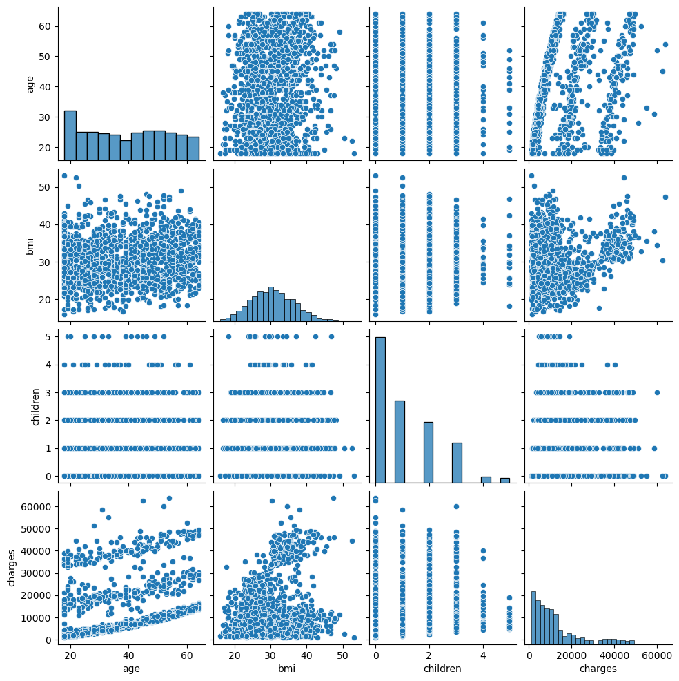

```python
sns.pairplot(df)
```

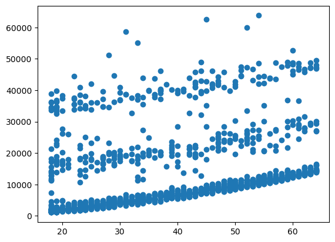

```python
# Criando um scatter plot

fig, ax = plt.subplots()

ax.scatter(df.age, df.charges)

plt.show()
```

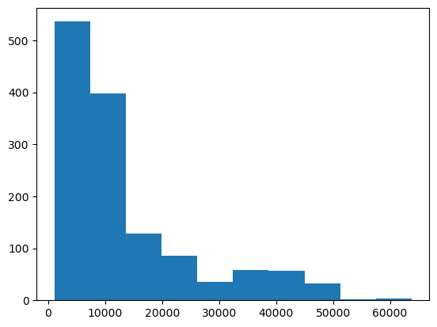

```python
# Visualizando o histograma dos dados:
fig, ax = plt.subplots()
ax.hist(df.charges, bins = 10)

plt.show()
```

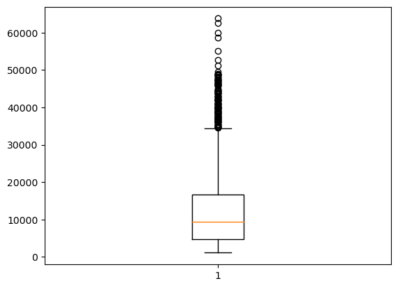

```python
# Verificando o boxplot:
fig, ax = plt.subplots()

ax.boxplot(df.charges)

plt.show()
```

```python
df.charges.describe()
```

```
count     1338.000000
mean     13270.422265
std      12110.011237
min       1121.873900
25%       4740.287150
50%       9382.033000
75%      16639.912515
max      63770.428010
Name: charges, dtype: float64
```

```python
# Criano uma matriz de correlação
df.corr()
```

|  | age | bmi | children | charges |
| --- | --- | --- | --- | --- |
| age | 1.000000 | 0.109272 | 0.042469 | 0.299008 |
| bmi | 0.109272 | 1.000000 | 0.012759 | 0.198341 |
| children | 0.042469 | 0.012759 | 1.000000 | 0.067998 |
| charges | 0.299008 | 0.198341 | 0.067998 | 1.000000 |

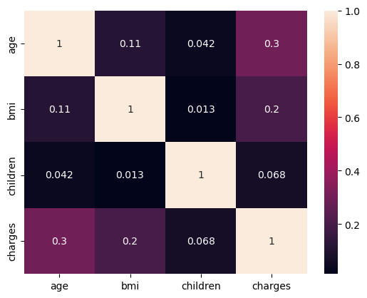

```python
sns.heatmap(df.corr(), annot=True)
plt.show()
```

# 4.Prediction_Model

## 4.1.First_Model

```python
df4_1 = df.copy()
```

Esse primeiro modelo será criado como base, ele será criado desconsiderando as colunas do tipo qualitativa, para temos um valor como base de forma inicial.

```python
# Criando uma lista com as colunas numéricas
col_num = df4_1.select_dtypes(include=['number']).columns.tolist()
```

```python
# Eliminando as colunas do tipo object:
print(f'Colunas presentes no dataset antes: {df4_1.info()}')
df4_1 = df4_1.loc[:, col_num]
print(f'Colunas presentes no dataset depois: {df4_1.info()}')
```

```
<class 'pandas.core.frame.DataFrame'>
RangeIndex: 1338 entries, 0 to 1337
Data columns (total 7 columns):
 #   Column    Non-Null Count  Dtype
---  ------    --------------  -----
 0   age       1338 non-null   int64
 1   sex       1338 non-null   object
 2   bmi       1338 non-null   float64
 3   children  1338 non-null   int64
 4   smoker    1338 non-null   object
 5   region    1338 non-null   object
 6   charges   1338 non-null   float64
dtypes: float64(2), int64(2), object(3)
memory usage: 73.3+ KB
Colunas presentes no dataset antes: None
<class 'pandas.core.frame.DataFrame'>
RangeIndex: 1338 entries, 0 to 1337
Data columns (total 4 columns):
 #   Column    Non-Null Count  Dtype
---  ------    --------------  -----
 0   age       1338 non-null   int64
 1   bmi       1338 non-null   float64
 2   children  1338 non-null   int64
 3   charges   1338 non-null   float64
dtypes: float64(2), int64(2)
memory usage: 41.9 KB
Colunas presentes no dataset depois: None
```

```python
# Selecionando X e y:
X = df4_1.drop(columns='charges', axis=1)
y = df4_1.charges
```

```python
# Separando a base em treino e teste:
X_train, X_test, y_train, y_test = train_test_split(X,
                                                    y,
                                                    test_size=0.33,
                                                    random_state=42)
```

```python
# Dicionários para armazenar métricas e informações dos modelos
modelos_erro_abs           = {}
modelos_erro_square        = {}
```

```python
np.random.seed(42)

modelos = {
    "LinearRegression": LinearRegression(),
    "Tree": tree.DecisionTreeRegressor(random_state=42),
    "KNN": KNeighborsRegressor(n_neighbors=250)
}
```

```python
# Função para Treinamento dos Modelos e Obtenção das métricas para cada
# modelo quando aplicado aos dados de teste
def fit_and_score(models, X_train, X_test, y_train, y_test):
    """
       Função com o objetivo de Treinar e Testar determinados modelos de Machine Learning
       modelos: Um dicionário de diferentes modelos de aprendizado de máquina do scikit-learn
       X_train: Dados de treinamento
       X_test: Dados de teste
       y_train: Valores reais de treino
       y_test: Valores reais de teste
    """
    # Dicionários para armazenar os erros
    modelos_erro_abs = {}
    modelos_erro_square = {}

    # Loop para o dicionário dos modelos
    for name, model in modelos.items():
        # Ajustando o modelo aos dados
        model.fit(X_train, y_train)

        # Calculando o Erro Médio Absoluto
        modelos_erro_abs[name] = mean_absolute_error(y_test, model.predict(X_test))

        # Calculando o Erro Quadrático Médio
        modelos_erro_square[name] = mean_squared_error(y_test, model.predict(X_test))

    # Gerar gráficos para cada modelo
    fig, ax = plt.subplots(ncols=len(modelos), figsize=(18, 5))
    for i, (name, model) in enumerate(modelos.items()):
        ax[i].scatter(y_test, model.predict(X_test))
        ax[i].plot([0, 70000], [0, 70000], '--r')
        ax[i].set_title(name)
        ax[i].set_xlabel('Valores reais')
        ax[i].set_ylabel('Previsões')
        ax[i].set(xlim=(0, 70000), ylim=(0, 70000))

    plt.show()

    # Exibir as métricas de erro
    print(f"====Modelos====\n")

    df_resultados = pd.DataFrame({
        "Erro_Absoluto": modelos_erro_abs,
        "Erro_Quadrático": modelos_erro_square,
    })
    print(df_resultados)
```

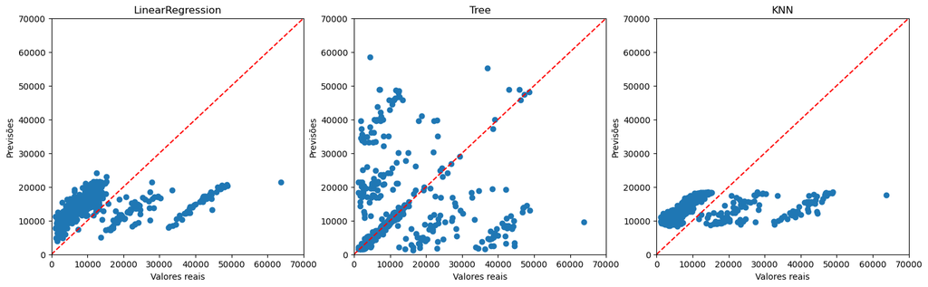

```
====Modelos====

                  Erro_Absoluto  Erro_Quadrático
LinearRegression    9061.788154     1.267424e+08
Tree               10490.550560     2.748450e+08
KNN                 9032.796719     1.303403e+08
Tempo de execução: 1.7503 segundos
```

```python
start_time = time.time()
#Chamando a função
model_scores = fit_and_score(
                             models = modelos,
                             X_train = X_train,
                             X_test = X_test,
                             y_train = y_train,
                             y_test = y_test)
model_scores

end_time =time.time()
print(f"Tempo de execução: {end_time - start_time:.4f} segundos")
```